# Лабораторная работа №2

Операционные системы

Мустафина А. Ю. НКАбд-03-24

Российский университет дружбы народов, Москва, Россия

7 марта 2025

## Цель работы

Изучить идеологию и применение средств контроля версий и освоить умения по работе с git.

## Задание

1. Создать базовую конфигурацию для работы с git.
2. Создать ключ SSH.
3. Создать ключ PGP.
4. Настроить подписи git.
5. Зарегистрироваться на Github.
6. Создать локальный каталог для выполнения заданий по предмету.

# Выполнение лабораторной работы

## Установка программного обеспечения

Устанавливаю программное обеспечение через терминал с помощью команд dnf install git и dnf install gh (рис. 1).

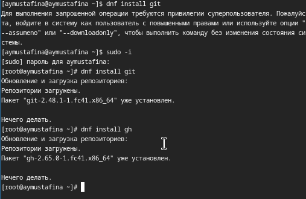

Установка

## Базовая настройка git

Задаю имя и email владельца репозитория с помощью команд: git config –global user.name “Name Surname” git config –global user.email “work@mail” (рис. 2).

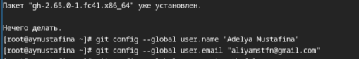

Имя и email

## Базовая настройка git

Настроим utf-8 в выводе сообщений git: git config –global core.quotepath false

Зададим имя начальной ветки (будем называть её master): git config –global init.defaultBranch master

Параметр autocrlf: git config –global core.autocrlf input

Параметр safecrlf: git config –global core.safecrlf warn (рис. 3).

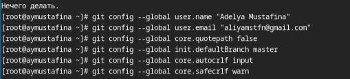

Базовая настройка

## Создание ключа ssh

по алгоритму rsa с ключём размером 4096 бит: ssh-keygen -t rsa -b 4096 (рис. 4).

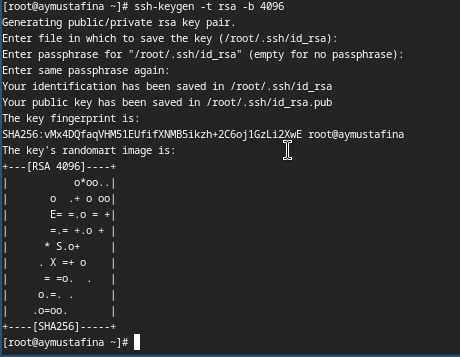

Создание ключа ssh по rsa

## Создание ключа ssh

по алгоритму ed25519: ssh-keygen -t ed25519 (рис. 5).

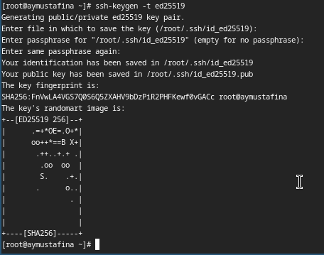

Создание ключа ssh по ed255519

## Создание ключа pgp

Генерирую ключ gpg –full-generate-key

Из предложенных опций выбираю: тип RSA and RSA; размер 4096; выбрала срок действия; значение по умолчанию — 0 (срок действия не истекает никогда). GPG запросит личную информацию, которая сохранится в ключе: Имя. Адрес электронной почты. При вводе email убеждаюсь, что он соответствует адресу, используемому на GitHub. Комментарий. Нажимаю клавишу ввода, чтобы оставить это поле пустым. (рис. 6).

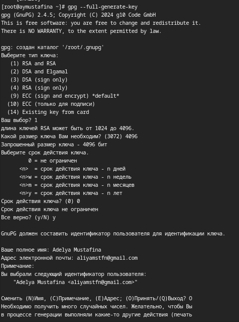

Генерирование ключа pgp

## Создание ключа pgp

Ввожу фразу-пароль для защиты ключа (рис. 7).

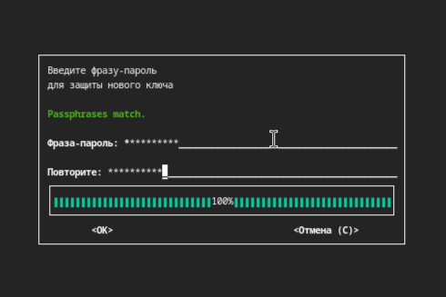

Фраза-пароль

## Создание ключа pgp

Открытый и секретный ключ созданы (рис. 8).

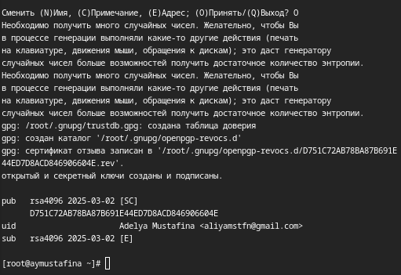

Создание ключей

## Настройка github

У меня уже был создан аккаунт на github, основные данные аккаунта заполнены (рис. 9).

[figure not shown]

Настройка github

## Добавление PGP ключа в GitHub

Вывожу список ключей и копирую отпечаток приватного ключа: gpg –list-secret-keys –keyid-format LONG

Отпечаток ключа — это последовательность байтов, используемая для идентификации более длинного, по сравнению с самим отпечатком (рис. 10).

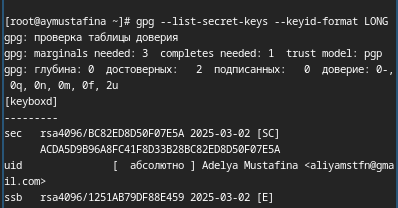

Вывод ключей

## Добавление PGP ключа в GitHub

Перехожу в настройки Github, нажимаю кнопку New GPG key и вставляю полученный ключ в поле ввода (рис. 12).

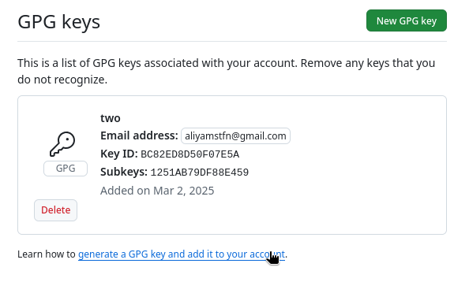

New GPG key

## Настройка автоматических подписей коммитов git

Используя введёный email, укажите Git применять его при подписи коммитов:

git config –global user.signingkey git config –global commit.gpgsign true git config –global gpg.program $(which gpg2) (рис. 13).

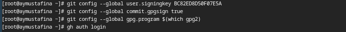

Настройка подписей git

## Настройка gh

Сначала аворизуюсь в gh, отвечаю на наводящие вопросы, в конце выбираю авторизацию через браузер (рис. 14).

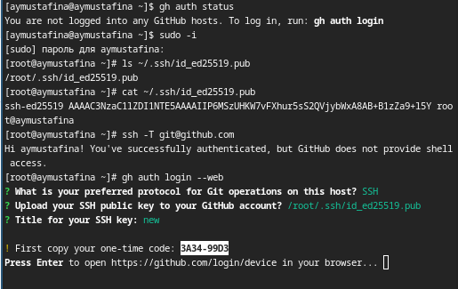

Автoризация в gh

## Настройка gh

Завершаю авторизацию на сайте (рис. 15).

[figure not shown]

Авторизация на сайте

## Настройка gh

Вижу сообщение о завершении авторизации на сайте (рис. 16).

[figure not shown]

Завершение авторизации

## Создание репозитория курса на основе шаблона

Сначала создаю директорию с помощью утилиты mkdir и с помощью cd перехожу в созданную директорию:

mkdir -p ~/work/study/2024-2025/“Операционные системы” cd ~/work/study/2024-2025/“Операционные системы” gh repo create study_2024-2025_os-intro –template=yamadharma/course-directory-student-template –public git clone –recursive git@github.com:/study_2024-2025_os-intro.git os-intro (рис. 18).

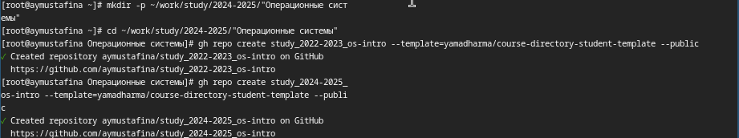

Создание репозитория курса

## Создание репозитория курса на основе шаблона

Клонирование репозитория (рис. 19).

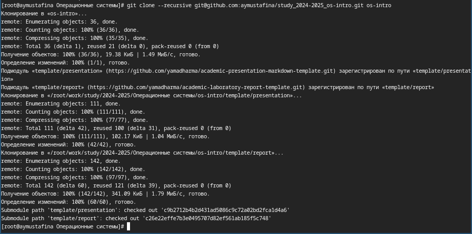

Клонирование репозитория курса

## Создание репозитория курса на основе шаблона

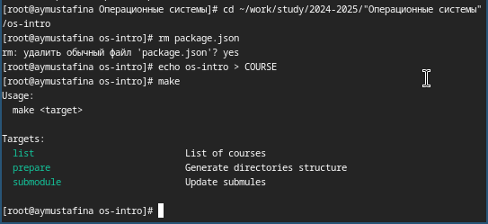

Редактирование созданного репозитория

## Создание репозитория курса на основе шаблона

Добавляю все новые файлы для отправки на сервер и комментирую их: git add . git commit -am ‘feat(main): make course structure’ (рис. 21).

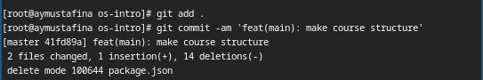

Отправка файлов на сервер

## Создание репозитория курса на основе шаблона

Отправляю файлы на сервер с помощью git push (рис. 22).

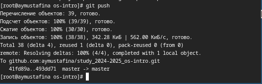

Отправка файлов

# Выводы

При выполнении данной лабораторной работы я изучила идеалогию и применение средств контроля версий, изучила команды для работы с git.

## Список литературы

1. Лабораторная работа №2